# imdb

```python
import numpy as np
import pandas as pd
import seaborn as sns
```

```python
im=pd.read_csv(r'C:\IMDB-Movie-Data.csv')
```

```python
im.head(5)
```

|  | Rank | Title | Genre | Description | Director | Actors | Year | Runtime (Minutes) | Rating | Votes | Revenue (Millions) | Metascore |
| --- | --- | --- | --- | --- | --- | --- | --- | --- | --- | --- | --- | --- |
| 0 | 1 | Guardians of the Galaxy | Action,Adventure,Sci-Fi | A group of intergalactic criminals are forced ... | James Gunn | Chris Pratt, Vin Diesel, Bradley Cooper, Zoe S... | 2014 | 121 | 8.1 | 757074 | 333.13 | 76.0 |
| 1 | 2 | Prometheus | Adventure,Mystery,Sci-Fi | Following clues to the origin of mankind, a te... | Ridley Scott | Noomi Rapace, Logan Marshall-Green, Michael Fa... | 2012 | 124 | 7.0 | 485820 | 126.46 | 65.0 |
| 2 | 3 | Split | Horror,Thriller | Three girls are kidnapped by a man with a diag... | M. Night Shyamalan | James McAvoy, Anya Taylor-Joy, Haley Lu Richar... | 2016 | 117 | 7.3 | 157606 | 138.12 | 62.0 |
| 3 | 4 | Sing | Animation,Comedy,Family | In a city of humanoid animals, a hustling thea... | Christophe Lourdelet | Matthew McConaughey,Reese Witherspoon, Seth Ma... | 2016 | 108 | 7.2 | 60545 | 270.32 | 59.0 |
| 4 | 5 | Suicide Squad | Action,Adventure,Fantasy | A secret government agency recruits some of th... | David Ayer | Will Smith, Jared Leto, Margot Robbie, Viola D... | 2016 | 123 | 6.2 | 393727 | 325.02 | 40.0 |

```python
im.shape
```

```
(1000, 12)
```

```python
type(im.shape)
```

```
tuple
```

```python
type(im.isnull().sum())
```

```
pandas.core.series.Series
```

```python
im.isnull().sum()
```

```
Rank                    0
Title                   0
Genre                   0
Description             0
Director                0
Actors                  0
Year                    0
Runtime (Minutes)       0
Rating                  0
Votes                   0
Revenue (Millions)    128
Metascore              64
dtype: int64
```

```python
im['Revenue (Millions)'].dropna(inplace=True)
```

```python
im.dropna(axis=0,inplace=True)
```

```python
im.isnull().sum()
```

```
Rank                  0
Title                 0
Genre                 0
Description           0
Director              0
Actors                0
Year                  0
Runtime (Minutes)     0
Rating                0
Votes                 0
Revenue (Millions)    0
Metascore             0
dtype: int64
```

duplicate values

```python
dup_data=im.duplicated().any()
```

```python
im.drop_duplicates()
```

```python
print('Are there any duplicate values?',dup_data)
```

```
Are there any duplicate values? False
```

```python
im.duplicated(keep=False)
```

```
0      False
1      False
2      False
3      False
4      False
       ...
993    False
994    False
996    False
997    False
999    False
Length: 838, dtype: bool
```

```python
im.describe(include='all')
```

[output not shown]

```python
im[['Runtime (Minutes)', 'Votes']].describe()
```

[output not shown]

Movies running time more than 180 minutes

```python
im.columns
```

```
Index(['Rank', 'Title', 'Genre', 'Description', 'Director', 'Actors', 'Year',
       'Runtime (Minutes)', 'Rating', 'Votes', 'Revenue (Millions)',
       'Metascore'],
      dtype='object')
```

```python
im[im['Runtime (Minutes)']>=180]['Title']
```

```
82     The Wolf of Wall Street
88           The Hateful Eight
311             La vie d'Adèle
Name: Title, dtype: object
```

Highest votes of the year.

```python
im.groupby('Year')['Votes'].mean().sort_values(ascending=False)
```

```
Year
2012    290861.483871
2006    277232.219512
2009    267180.577778
2008    266580.145833
2007    266530.704545
2010    261082.929825
2011    259254.736842
2013    225531.892857
2014    211926.881720
2015    129512.651376
2016     68437.823232
Name: Votes, dtype: float64
```

```python
im.sort_values(['Year','Votes'],ascending=False).groupby('Year').mean()['Votes']
```

```
Year
2006    269289.954545
2007    244331.037736
2008    275505.384615
2009    255780.647059
2010    252782.316667
2011    240790.301587
2012    285226.093750
2013    219049.648352
2014    203930.224490
2015    115726.220472
2016     48591.754209
Name: Votes, dtype: float64
```

```python
im[['Year','Votes']].sort_values(['Year'],ascending=False).groupby('Year').mean()
```

| Year | Votes |
| --- | --- |
| 2006 | 269289.954545 |
| 2007 | 244331.037736 |
| 2008 | 275505.384615 |
| 2009 | 255780.647059 |
| 2010 | 252782.316667 |
| 2011 | 240790.301587 |
| 2012 | 285226.093750 |
| 2013 | 219049.648352 |
| 2014 | 203930.224490 |
| 2015 | 115726.220472 |
| 2016 | 48591.754209 |

Highest average revenue of the year.

```python
im.groupby('Year')['Revenue (Millions)'].mean().sort_values(ascending=False)
```

```
Year
2009    115.742000
2012    110.103065
2010    105.081579
2008     97.525417
2011     93.703333
2007     93.074091
2013     88.084643
2006     87.255610
2014     85.433656
2015     80.725596
2016     55.566111
Name: Revenue (Millions), dtype: float64
```

Average ratings per ratings for directors.

```python
im.groupby('Director')['Rating'].mean().sort_values(ascending=False)
```

```
Director
Christopher Nolan                   8.68
Olivier Nakache                     8.60
Makoto Shinkai                      8.60
Florian Henckel von Donnersmarck    8.50
Aamir Khan                          8.50
                                    ...
Sam Taylor-Johnson                  4.10
Joey Curtis                         4.00
George Nolfi                        3.90
James Wong                          2.70
Jason Friedberg                     1.90
Name: Rating, Length: 524, dtype: float64
```

Top 10 lengthy movies title and runtime.

```python
im.columns
```

```
Index(['Rank', 'Title', 'Genre', 'Description', 'Director', 'Actors', 'Year',
       'Runtime (Minutes)', 'Rating', 'Votes', 'Revenue (Millions)',
       'Metascore'],
      dtype='object')
```

```python
im['Runtime (Minutes)'].max()
```

```
187
```

```python
im.groupby('Title')['Runtime (Minutes)'].max().sort_values(ascending=False).head(10)
```

```
Title
The Hateful Eight                           187
The Wolf of Wall Street                     180
La vie d'Adèle                              180
Cloud Atlas                                 172
3 Idiots                                    170
Interstellar                                169
Pirates of the Caribbean: At World's End    169
The Hobbit: An Unexpected Journey           169
The Curious Case of Benjamin Button         166
Django Unchained                            165
Name: Runtime (Minutes), dtype: int64
```

Display number of movies per year

```python
im.groupby('Year')['Title'].count().sort_values(ascending=False)
```

[output not shown]

Most popular movie title

```python
im.groupby('Title')['Revenue (Millions)'].max().sort_values(ascending=False).head(10)
```

```
Title
Star Wars: Episode VII - The Force Awakens    936.63
Avatar                                        760.51
Jurassic World                                652.18
The Avengers                                  623.28
The Dark Knight                               533.32
Rogue One                                     532.17
Finding Dory                                  486.29
Avengers: Age of Ultron                       458.99
The Dark Knight Rises                         448.13
The Hunger Games: Catching Fire               424.65
Name: Revenue (Millions), dtype: float64
```

```python
im[['Title','Revenue (Millions)']].sort_values(by='Revenue (Millions)',ascending=False).head(10)
```

|  | Title | Revenue (Millions) |
| --- | --- | --- |
| 50 | Star Wars: Episode VII - The Force Awakens | 936.63 |
| 87 | Avatar | 760.51 |
| 85 | Jurassic World | 652.18 |
| 76 | The Avengers | 623.28 |
| 54 | The Dark Knight | 533.32 |
| 12 | Rogue One | 532.17 |
| 119 | Finding Dory | 486.29 |
| 94 | Avengers: Age of Ultron | 458.99 |
| 124 | The Dark Knight Rises | 448.13 |
| 578 | The Hunger Games: Catching Fire | 424.65 |

Average ratings of movies per year

```python
im.groupby('Year')['Rating'].mean().sort_values(ascending=False)
```

```
Year
2007    7.133962
2006    7.125000
2009    6.960784
2012    6.925000
2011    6.838095
2014    6.837755
2010    6.826667
2013    6.812088
2008    6.784615
2015    6.602362
2016    6.436700
Name: Rating, dtype: float64
```

Does rating affect the revenue

```python
im.columns
```

```
Index(['Rank', 'Title', 'Genre', 'Description', 'Director', 'Actors', 'Year',
       'Runtime (Minutes)', 'Rating', 'Votes', 'Revenue (Millions)',
       'Metascore'],
      dtype='object')
```

```python
im.sort_values(by='Revenue (Millions)',ascending=False)
```

[output not shown]

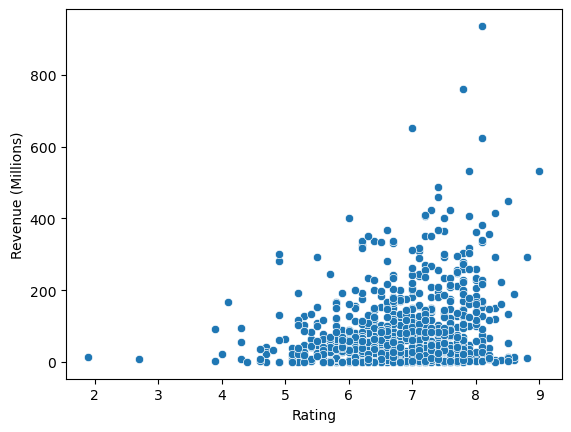

```python
sns.scatterplot(x='Rating',y='Revenue (Millions)',data=im)
```

```python
im.head(5)
```

|  | Rank | Title | Genre | Description | Director | Actors | Year | Runtime (Minutes) | Rating | Votes | Revenue (Millions) | Metascore |
| --- | --- | --- | --- | --- | --- | --- | --- | --- | --- | --- | --- | --- |
| 0 | 1 | Guardians of the Galaxy | Action,Adventure,Sci-Fi | A group of intergalactic criminals are forced ... | James Gunn | Chris Pratt, Vin Diesel, Bradley Cooper, Zoe S... | 2014 | 121 | 8.1 | 757074 | 333.13 | 76.0 |
| 1 | 2 | Prometheus | Adventure,Mystery,Sci-Fi | Following clues to the origin of mankind, a te... | Ridley Scott | Noomi Rapace, Logan Marshall-Green, Michael Fa... | 2012 | 124 | 7.0 | 485820 | 126.46 | 65.0 |
| 2 | 3 | Split | Horror,Thriller | Three girls are kidnapped by a man with a diag... | M. Night Shyamalan | James McAvoy, Anya Taylor-Joy, Haley Lu Richar... | 2016 | 117 | 7.3 | 157606 | 138.12 | 62.0 |
| 3 | 4 | Sing | Animation,Comedy,Family | In a city of humanoid animals, a hustling thea... | Christophe Lourdelet | Matthew McConaughey,Reese Witherspoon, Seth Ma... | 2016 | 108 | 7.2 | 60545 | 270.32 | 59.0 |
| 4 | 5 | Suicide Squad | Action,Adventure,Fantasy | A secret government agency recruits some of th... | David Ayer | Will Smith, Jared Leto, Margot Robbie, Viola D... | 2016 | 123 | 6.2 | 393727 | 325.02 | 40.0 |

classifying movies based on ratings [excellent,good and Average]

```python
im.columns
```

```
Index(['Rank', 'Title', 'Genre', 'Description', 'Director', 'Actors', 'Year',
       'Runtime (Minutes)', 'Rating', 'Votes', 'Revenue (Millions)',
       'Metascore'],
      dtype='object')
```

```python
def rating(rating):
    if rating>=7.0:
        return 'excellent'
    elif rating>=6.0:
        return 'good'
    else:
        return 'average'
```

```python
im['rating_class']=im['Rating'].apply(rating)
```

```python
im.head(5)
```

|  | Rank | Title | Genre | Description | Director | Actors | Year | Runtime (Minutes) | Rating | Votes | Revenue (Millions) | Metascore | rating_class |
| --- | --- | --- | --- | --- | --- | --- | --- | --- | --- | --- | --- | --- | --- |
| 0 | 1 | Guardians of the Galaxy | Action,Adventure,Sci-Fi | A group of intergalactic criminals are forced ... | James Gunn | Chris Pratt, Vin Diesel, Bradley Cooper, Zoe S... | 2014 | 121 | 8.1 | 757074 | 333.13 | 76.0 | excellent |
| 1 | 2 | Prometheus | Adventure,Mystery,Sci-Fi | Following clues to the origin of mankind, a te... | Ridley Scott | Noomi Rapace, Logan Marshall-Green, Michael Fa... | 2012 | 124 | 7.0 | 485820 | 126.46 | 65.0 | excellent |
| 2 | 3 | Split | Horror,Thriller | Three girls are kidnapped by a man with a diag... | M. Night Shyamalan | James McAvoy, Anya Taylor-Joy, Haley Lu Richar... | 2016 | 117 | 7.3 | 157606 | 138.12 | 62.0 | excellent |
| 3 | 4 | Sing | Animation,Comedy,Family | In a city of humanoid animals, a hustling thea... | Christophe Lourdelet | Matthew McConaughey,Reese Witherspoon, Seth Ma... | 2016 | 108 | 7.2 | 60545 | 270.32 | 59.0 | excellent |
| 4 | 5 | Suicide Squad | Action,Adventure,Fantasy | A secret government agency recruits some of th... | David Ayer | Will Smith, Jared Leto, Margot Robbie, Viola D... | 2016 | 123 | 6.2 | 393727 | 325.02 | 40.0 | good |

Number of action movies

```python
im['Genre'].dtype
```

```
dtype('O')
```

```python
len(im[im['Genre'].str.contains('Action',case=False)])
```

```
303
```

```python
im.columns
```

```
Index(['Rank', 'Title', 'Genre', 'Description', 'Director', 'Actors', 'Year',
       'Runtime (Minutes)', 'Rating', 'Votes', 'Revenue (Millions)',
       'Metascore', 'rating_class'],
      dtype='object')
```

```python
im['Rating'].apply(lambda x:'excellent'if x>=7.5 else 'good'if x>=6.0 else 'average')
```

[output not shown]

```python
im['classified_scores']=im['Rating'].apply(lambda x:'excellent'if x>=7.5 else 'good'if x>=6.0 else 'average')
```

```python
im.head(2)
```

[output not shown]

```python
im.drop('lambda_check',axis=1,inplace=True)
```

```python
im.head(2)
```

[output not shown]

Find the movies with higest and lowest ratings

```python
im.columns
```

[output not shown]

```python
im.groupby('Title')['Rating'].max().sort_values(ascending=False)
```

```
Title
The Dark Knight             9.0
Inception                   8.8
Kimi no na wa               8.6
The Intouchables            8.6
Interstellar                8.6
                           ...
2307: Winter's Dream        4.0
The Disappointments Room    3.9
Birth of the Dragon         3.9
Dragonball Evolution        2.7
Disaster Movie              1.9
Name: Rating, Length: 837, dtype: float64
```

Determine the year with the highest number of movies released.

```python
im['Year'].value_counts()
```

```
2016    198
2015    109
2014     93
2013     84
2012     62
2011     57
2010     57
2008     48
2009     45
2007     44
2006     41
Name: Year, dtype: int64
```

filter movies released after the year 2015

```python
im['Year']=2015
movies_released=im[im['Year']>2015]
print(movies_released)
```

```
Empty DataFrame
Columns: [Rank, Title, Genre, Description, Director, Actors, Year, Runtime (Minutes), Rating, Votes, Revenue (Millions), Metascore]
Index: []
```

Filter the dataset to show only movies with a rating above a certain threshold

```python
tresh_abv=7.0
movies_abv_70=im[im['Rating']>tresh_abv].copy()
print(movies_abv_70)
```

```
     Rank                    Title                       Genre  \
0       1  Guardians of the Galaxy     Action,Adventure,Sci-Fi
2       3                    Split             Horror,Thriller
3       4                     Sing     Animation,Comedy,Family
6       7               La La Land          Comedy,Drama,Music
8       9       The Lost City of Z  Action,Adventure,Biography
..    ...                      ...                         ...
959   960      Lucky Number Slevin         Crime,Drama,Mystery
974   975           Queen of Katwe       Biography,Drama,Sport
979   980       The Skin I Live In              Drama,Thriller
982   983      Across the Universe       Drama,Fantasy,Musical
991   992         Taare Zameen Par          Drama,Family,Music

                                           Description              Director  \
0    A group of intergalactic criminals are forced ...            James Gunn
```

[output cut: 38 more lines]

Select movies that belong to a specific genre (e.g., "Action").

```python
im.columns
```

```
Index(['Rank', 'Title', 'Genre', 'Description', 'Director', 'Actors', 'Year',
       'Runtime (Minutes)', 'Rating', 'Votes', 'Revenue (Millions)',
       'Metascore'],
      dtype='object')
```

```python
action_movies=im[im['Genre'].str.contains('Action')]
print(action_movies)
```

```
Empty DataFrame
Columns: [Rank, Title, Genre, Description, Director, Actors, Year, Runtime (Minutes), Rating, Votes, Revenue (Millions), Metascore]
Index: []
```

Group the data by year and calculate the average revenue for each year.

```python
im.groupby('Year')['Revenue (Millions)'].mean()
```

```
Year
2015    84.564558
Name: Revenue (Millions), dtype: float64
```

Group the data by director and find the director with the most movies in the dataset.

```python
im.head()
```

|  | Rank | Title | Genre | Description | Director | Actors | Year | Runtime (Minutes) | Rating | Votes | Revenue (Millions) | Metascore |
| --- | --- | --- | --- | --- | --- | --- | --- | --- | --- | --- | --- | --- |
| 0 | 1 | Guardians of the Galaxy | True | A group of intergalactic criminals are forced ... | James Gunn | Chris Pratt, Vin Diesel, Bradley Cooper, Zoe S... | 2015 | 121 | 8.1 | 757074 | 333.13 | 76.0 |
| 1 | 2 | Prometheus | False | Following clues to the origin of mankind, a te... | Ridley Scott | Noomi Rapace, Logan Marshall-Green, Michael Fa... | 2015 | 124 | 7.0 | 485820 | 126.46 | 65.0 |
| 2 | 3 | Split | False | Three girls are kidnapped by a man with a diag... | M. Night Shyamalan | James McAvoy, Anya Taylor-Joy, Haley Lu Richar... | 2015 | 117 | 7.3 | 157606 | 138.12 | 62.0 |
| 3 | 4 | Sing | False | In a city of humanoid animals, a hustling thea... | Christophe Lourdelet | Matthew McConaughey,Reese Witherspoon, Seth Ma... | 2015 | 108 | 7.2 | 60545 | 270.32 | 59.0 |
| 4 | 5 | Suicide Squad | True | A secret government agency recruits some of th... | David Ayer | Will Smith, Jared Leto, Margot Robbie, Viola D... | 2015 | 123 | 6.2 | 393727 | 325.02 | 40.0 |

```python
director_movie_count = im['Director'].value_counts()
director_with_most_movies = director_movie_count.idxmax()
number_of_movies = director_movie_count.max()
print(f"The director with the most movies is {director_with_most_movies} with {number_of_movies} movies.")
```

```
The director with the most movies is Ridley Scott with 8 movies.
```

```python
director_most_movies = im['Director'].value_counts().idxmax()
number_of_movies = im['Director'].value_counts().max()

print(f"The director with the most movies is {director_most_movies} with {number_of_movies} movies.")
```

```
The director with the most movies is Ridley Scott with 8 movies.
```

Group the data by actor and find the actor with the highest average movie rating.

```python
im.columns
```

```
Index(['Rank', 'Title', 'Genre', 'Description', 'Director', 'Actors', 'Year',
       'Runtime (Minutes)', 'Rating', 'Votes', 'Revenue (Millions)',
       'Metascore'],
      dtype='object')
```

```python
# Group the data by actor and calculate the average movie rating
actor_ratings =im.groupby('Actors')['Rating'].mean()
# Find the actor with the highest average rating
actor_with_highest_rating = actor_ratings.idxmax()
highest_average_rating = actor_ratings.max()
print(f"The actor with the highest average movie rating is {actor_with_highest_rating} with an average rating of {highest_average_rating}")
```

```
The actor with the highest average movie rating is Christian Bale, Heath Ledger, Aaron Eckhart,Michael Caine with an average rating of 9.0
```

```python
print(actor_ratings)
```

```
Actors
Aamir Khan, Anushka Sharma, Sanjay Dutt,Boman Irani                          8.2
Aamir Khan, Madhavan, Mona Singh, Sharman Joshi                              8.4
Aamir Khan, Sakshi Tanwar, Fatima Sana Shaikh,Sanya Malhotra                 8.8
Aaron Paul, Dominic Cooper, Imogen Poots, Scott Mescudi                      6.5
Aaron Poole, Kenneth Welsh,Daniel Fathers, Kathleen Munroe                   5.8
                                                                            ...
Zachary Gordon, Robert Capron, Rachael Harris,Steve Zahn                     6.2
Zoey Deutch, James Franco, Tangie Ambrose,Cedric the Entertainer             6.3
Zoey Deutch, Lucy Fry, Danila Kozlovsky, Gabriel Byrne                       5.6
Zoey Deutch, Nicholas Braun, Mateo Arias, Israel Broussard                   6.1
Zooey Deschanel, Joseph Gordon-Levitt, Geoffrey Arend, Chloë Grace Moretz    7.7
Name: Rating, Length: 996, dtype: float64
```

```python
print(actor_with_highest_rating)
```

```
Christian Bale, Heath Ledger, Aaron Eckhart,Michael Caine
```

```python
highest_revenue=im.groupby('Year')['Revenue (Millions)'].max().sort_values(ascending=False)
lowest_revenue=highest_revenue.min()
print(lowest_revenue)
```

[output not shown]

```python
im.groupby('Year')['Revenue (Millions)'].max().sort_values(ascending=False)
```

[output not shown]

Calculate the total revenue and average rating for each director. Who is the director with the highest average rating?

```python
im.columns
```

```
Index(['Rank', 'Title', 'Genre', 'Description', 'Director', 'Actors', 'Year',
       'Runtime (Minutes)', 'Rating', 'Votes', 'Revenue (Millions)',
       'Metascore'],
      dtype='object')
```

```python
grouped_directors=im.groupby('Director').agg({'Revenue (Millions)':'sum','Rating':'mean'})
print(grouped_directors)
highest_rating=grouped_directors['Rating'].idxmax()
print(highest_rating)
print(f"director with the highest average rating is {highest_rating}")
```

```
                     Revenue (Millions)  Rating
Director
Aamir Khan                         1.20    8.50
Abdellatif Kechiche                2.20    7.80
Adam Leon                          0.00    6.50
Adam McKay                       438.14    7.00
Adam Shankman                    157.33    6.30
...                                 ...     ...
Xavier Dolan                       3.49    7.55
Yimou Zhang                       45.13    6.10
Yorgos Lanthimos                   8.81    7.20
Zack Snyder                      975.74    7.04
Zackary Adler                      6.53    5.10

[644 rows x 2 columns]
Nitesh Tiwari
director with the highest average rating is Nitesh Tiwari
```

Group the data by year, then calculate the total number of movies for each combination of the year.

```python
grouped_year=im.groupby('Year')['Title'].count().sort_values(ascending=False)
print(grouped_year)
```

[output not shown]

```python
im.columns
```

```
Index(['Rank', 'Title', 'Genre', 'Description', 'Director', 'Actors', 'Year',
       'Runtime (Minutes)', 'Rating', 'Votes', 'Revenue (Millions)',
       'Metascore'],
      dtype='object')
```

```python
highest_movie_rates=im.groupby('Title')['Rating'].max()
lowest_movie_rates=highest_movie_rates.min()

top_5_movies=highest_movie_rates.idxmax()
print(top_5_movies)
```

```
The Dark Knight
```

```python
highest_movie_rates=im.groupby('Title')['Rating'].max().head(5)
print(highest_movie_rates)
```

```
Title
(500) Days of Summer    7.7
10 Cloverfield Lane     7.2
10 Years                6.1
12 Years a Slave        8.1
127 Hours               7.6
Name: Rating, dtype: float64
```

```python
lowest_movie_rates=im.nsmallest(5, 'Rating').reset_index()
print(lowest_movie_rates)
```

[output not shown]

```python
lowest_movie_ratings_subset=lowest_movie_rates[['Title', 'Rating']]
print(lowest_movie_ratings_subset)
```

```
                     Title  Rating
0           Disaster Movie     1.9
1  Don't Fuck in the Woods     2.7
2     Dragonball Evolution     2.7
3                 Tall Men     3.2
4               The Intent     3.5
```